# R Notebook

```r
options(na.action = "na.fail")
options(dplyr.summarise.inform = FALSE)
knitr::opts_chunk$set(cache.path = "cache/")

library(dplyr)
library(magrittr)
library(ggplot2)
library(grid)
library(gridExtra)
library(corrplot)
library(tsfeatures)
library(ranger)
library(caret)
```

```r
## extract trip zip contents to new dirs train & test
unzip(paste0(getwd(), "/trip_data_train.zip"), junkpaths = T, exdir = "train")
unzip(paste0(getwd(), "/trip_data_test.zip"), junkpaths = T, exdir = "test")
```

```r
list.files("train/") %>% glimpse
```

```
 chr [1:1000] "0000.csv" "0001.csv" "0002.csv" "0003.csv" "0004.csv" "0005.csv" "0006.csv" "0007.csv" "0008.csv" "0009.csv" "0010.csv" "0011.csv" "0012.csv" "0013.csv" ...
```

```r
list.files("test/") %>% glimpse
```

```
 chr [1:876] "1000.csv" "1001.csv" "1002.csv" "1003.csv" "1004.csv" "1005.csv" "1006.csv" "1007.csv" "1008.csv" "1009.csv" "1010.csv" "1011.csv" "1012.csv" "1013.csv" ...
```

# Train data

```r
train_raw <- read.csv("model_data_train.csv") %>% as_tibble
glimpse(train_raw)
```

```
Rows: 1,000
Columns: 16
$ filename  <chr> "0000.csv", "0001.csv", "0002.csv", "0003.csv", "0004.csv", "0005.csv", "0006.csv", "0007.csv", "0008.csv", "0009.csv", "0010.csv", "0011.csv", "0012.c…
$ feature1  <chr> "False", "False", "False", "False", "False", "False", "False", "False", "False", "False", "False", "False", "False", "False", "False", "True", "False",…
$ feature2  <chr> "False", "False", "False", "False", "False", "False", "False", "False", "False", "False", "False", "False", "False", "False", "False", "False", "False"…
$ feature3  <chr> "True", "False", "True", "True", "False", "False", "True", "True", "True", "True", "True", "True", "True", "False", "True", "True", "False", "False", "…
$ feature4  <dbl> 5.209096, 4.450941, 5.396552, 4.970163, 5.266868, 5.423508, 4.261212, 5.807669, 4.778476, 4.306586, 4.661677, 3.508351, 4.648357, 6.604351, 3.601953, 5…
$ feature5  <dbl> 9789.262, 10552.522, 10233.433, 10829.057, 10678.704, 8884.565, 9896.064, 9706.998, 10459.225, 11439.244, 9955.615, 11392.881, 9084.889, 8174.057, 9902…
$ feature6  <dbl> 30753.87, 33151.73, 32149.28, 34020.49, 33548.14, 27911.68, 31089.40, 30495.43, 32858.62, 35937.44, 31276.49, 35791.79, 28541.02, 25679.56, 31110.02, 3…
$ feature7  <dbl> 0.0010104224, 0.0009997680, 0.0010145655, 0.0009929965, 0.0010094189, 0.0009849606, 0.0009940801, 0.0010043707, 0.0009877837, 0.0010045927, 0.000993359…
$ feature8  <int> 5, 3, 6, 4, 6, 4, 6, 2, 7, 6, 5, 4, 6, 5, 7, 8, 7, 3, 8, 8, 3, 1, 7, 5, 8, 8, 6, 3, 5, 6, 5, 7, 5, 5, 4, 7, 4, 3, 4, 5, 6, 6, 6, 7, 7, 8, 6, 6, 4, 6, 5…
$ feature9  <int> 13, 11, 13, 8, 11, 9, 11, 8, 15, 12, 5, 7, 9, 10, 8, 8, 12, 10, 13, 7, 7, 11, 10, 10, 8, 11, 10, 9, 17, 14, 7, 13, 11, 11, 10, 11, 11, 11, 7, 5, 10, 10…
$ feature10 <int> 1, 1, 1, 1, 1, 1, 1, 1, 1, 1, 1, 1, 1, 1, 1, 1, 1, 1, 1, 1, 1, 1, 1, 1, 1, 1, 1, 1, 1, 1, 1, 1, 1, 1, 1, 1, 1, 1, 1, 1, 1, 1, 1, 1, 1, 1, 1, 1, 1, 1, 1…
$ feature11 <dbl> 9.373984e+03, 4.251619e+04, 1.305321e+07, 1.131908e+03, 3.163256e+03, 6.801067e+05, 6.486637e+03, 3.261819e+04, 8.394154e+02, 1.681729e+06, 8.258003e+0…
$ feature12 <dbl> 3.179204e-01, 2.229321e+00, 3.425951e+01, 2.576871e+01, 1.451544e+02, 5.726489e-03, 5.909947e-04, 1.308840e+02, 8.729170e-01, 2.634562e-04, 2.074521e-0…
$ feature13 <dbl> 9.379193e+03, 4.252064e+04, 1.305322e+07, 1.136878e+03, 3.168523e+03, 6.801121e+05, 6.490899e+03, 3.262400e+04, 8.441939e+02, 1.681733e+06, 8.304620e+0…
$ feature14 <dbl> 4.974085, 3.151531, 6.236594, 3.968008, 5.999782, 3.974651, 6.154283, 2.071923, 6.908172, 6.063219, 4.862412, 4.015952, 5.878807, 4.901317, 7.040475, 8…
$ y         <int> 0, 0, 0, 1, 0, 1, 1, 0, 0, 0, 1, 1, 1, 0, 0, 0, 0, 0, 0, 1, 1, 0, 1, 1, 1, 0, 0, 0, 0, 0, 1, 0, 0, 0, 0, 0, 0, 1, 1, 1, 0, 0, 0, 1, 1, 0, 1, 0, 0, 1, 0…
```

We will convert `feature1:feature3` to the factor class for modeling. We may also want `y` as a factor, depending on the libraries we use.

```r
train_raw %<>%
  mutate(feature1 = feature1 %>% as.factor(),
         feature2 = feature2 %>% as.factor(),
         feature3 = feature3 %>% as.factor(),
         y_fctr = paste0("Class_", y) %>% as.factor ) %>%
  select(-y)
```

## Correlation analysis

We plot the correlation matrix in order to understand linear relationships between the features

```
the standard deviation is zero
```

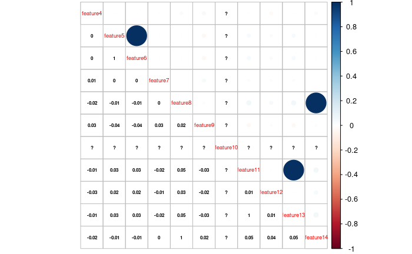

```r
train_raw %>%
  select_if(is.numeric) %>% ## exclude response and boolean types
  as.matrix() %>%
  cor() %>%
  corrplot.mixed(lower.col = "black",  number.cex = .5, tl.cex = .6)
```

Let’s also check the 3 boolean-esque type columns

```r
train_raw %>% select(2, 4, 3) %>% table
```

```
, , feature2 = False

        feature3
feature1 False True
   False   439  459
   True     54   48
```

We make the following observations:

1. `feature11` and `feature13` are co-linear
2. `feature5` and `feature6` are co-linear
3. `feature8` and `feature14` are co-linear
4. `feature10` and `feature2` are both zero-variance (all observations are “False” for `feature2`)
5. the remaining features are near perfectly independent of each other

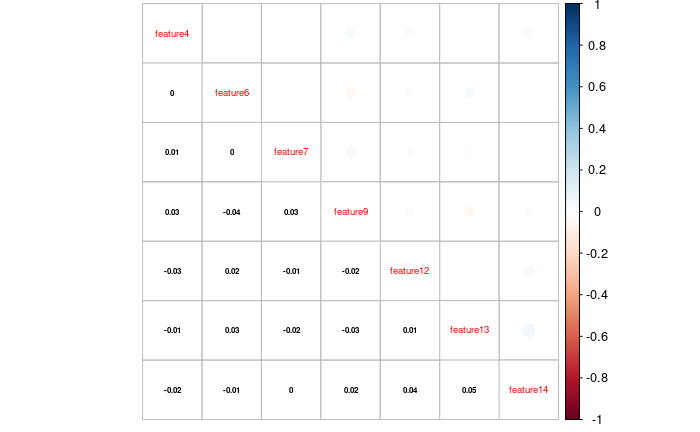

## Distribution analysis

Let’s also look at the distributions for each feature. This may inform modeling decisions later on - for example, what transformations we apply to raw features.

```r
summary(train_raw[,-1])
```

```
  feature1    feature3      feature4        feature6        feature7            feature9       feature12           feature13           feature14           y_fctr
 False:898   False:493   Min.   :2.116   Min.   :22599   Min.   :0.0009710   Min.   : 2.00   Min.   :      0.0   Min.   :4.000e+00   Min.   : 0.8254   Class_0:690
 True :102   True :507   1st Qu.:4.324   1st Qu.:29264   1st Qu.:0.0009934   1st Qu.: 8.00   1st Qu.:      0.1   1st Qu.:8.010e+02   1st Qu.: 3.9806   Class_1:310
                         Median :4.991   Median :31294   Median :0.0010007   Median :10.00   Median :      2.7   Median :2.295e+04   Median : 4.9881
                         Mean   :4.985   Mean   :31346   Mean   :0.0010004   Mean   :10.05   Mean   :   8845.5   Mean   :8.861e+08   Mean   : 4.9762
                         3rd Qu.:5.675   3rd Qu.:33548   3rd Qu.:0.0010069   3rd Qu.:12.00   3rd Qu.:     78.3   3rd Qu.:6.395e+05   3rd Qu.: 6.0227
                         Max.   :8.819   Max.   :40275   Max.   :0.0010345   Max.   :22.00   Max.   :1572134.4   Max.   :6.070e+11   Max.   :10.3276
```

Most features are ‘well-behaved’. For example `feature 4` is reasonably symmetric without extreme tails

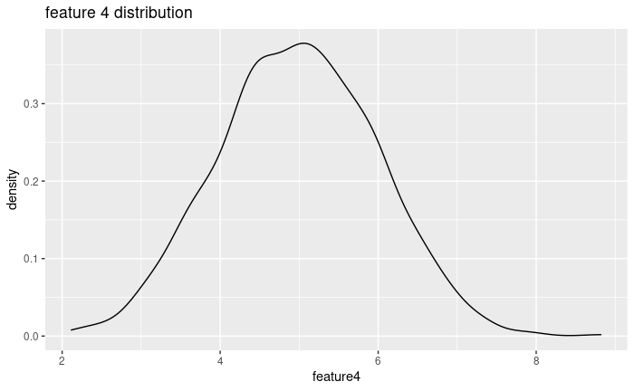

```r
train_raw %>% ggplot(aes(feature4)) + geom_density() + ggtitle("feature 4 distribution")
```

`feature12` and `feature13` stand out as being highly right-skewed. See for example the density for `feature12`.

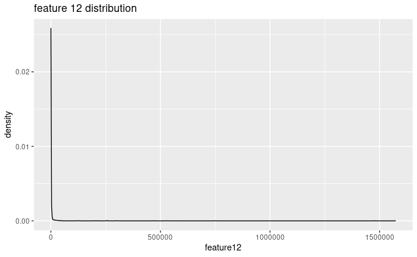

We may consider transforming these features later (for example, taking logs), but depending on the modeling approach (some algorithms being invariant to monotonic transforms).

## Trip data

We will consider extracting new features from the trip data files. Let’s start by getting a feel for a single trip time series.

```r
## Picking any trip
trip <- read.csv("train/0001.csv")
rbind(head(trip, 10), tail(trip, 10))
```

|  | time_seconds | speed_meters_per_second | heading_degrees |
| --- | --- | --- | --- |
| 1 | 0.000 | 9.1700000 | NA |
| 2 | 0.994 | 9.3111780 | NA |
| 3 | 1.711 | 11.1844635 | NA |
| 4 | 2.711 | 11.8209620 | 89.5722800 |
| 5 | 3.711 | 12.1415920 | 89.3347950 |
| 6 | 4.711 | 13.0594720 | 89.0973100 |
| 7 | 5.711 | 13.5775630 | 88.8332650 |
| 8 | 6.711 | 13.9788720 | 88.6748380 |
| 9 | 7.711 | 13.9118270 | 88.3704000 |
| 10 | 8.711 | 13.7187170 | 88.1609560 |

[output cut: 10 more lines]

Trips have a time for each reading which tends to be taken at a 1-second frequency, with possible exception at the start of the trip; they also have a speed reading (meters per second) and a heading (clockwise angle against magnetic north), although the nominal heading may not be as important as changes in heading (turning).

Noticing there may be missing data at the beginning and ending of a trip, we will impute missing values via NOCB (next obs. carried backward) for the start, and the reverse (LOCF) at the tail. This is not necessarily a strong approach for missing data in the middle of a series, though it has the virtue that it will not fail.

Let’s plot the trip series

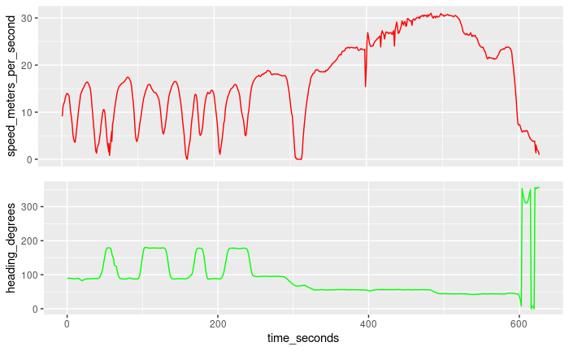

The sharp spikes at the end of the trip stand out - we need to account for the fact that with headings, the difference between 359 and 0 is more likely a 1 degree turn than a 359 degree turn. We will use the following formula when measuring the degree of turn, denoted D:

$$D = (h_t - h_{t-1} + 540) \pmod{360} - 180$$

This optimized formulation avoids comparison logic around nominal heading and references the input values (current and previous heading) just once. Let’s take first-order differences to get a feel for acceleration, and we will use the formula above to express the change in heading.

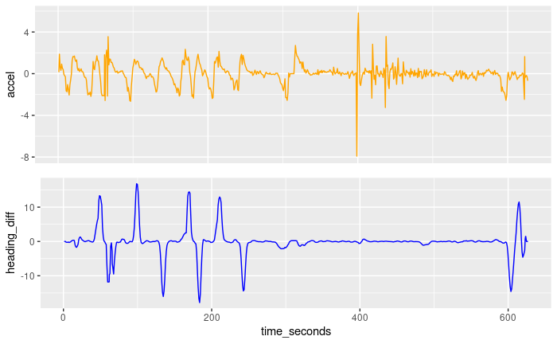

### Turning

Now we think about identifying turns. Our intuition tells us they should be characterized by:

1. consecutive runs (given sampling) of substantial heading changes (first order differencing) of the same sign;
2. the turn (run) should not be too long a duration, given the vehicle is moving (this may indicate road curvature rather than turning);
3. the magnitude of the sum of heading differences within a run must exceed some threshold
- stated another way, the difference between the ending and the starting heading should exceed some threshold
1. they also should correspond with travel at some appreciable velocity (not idling in place - this could occur due to instrument/measurement error) but also below some threshold velocity (which could again indicate taking curves at high speed).

We will threshold a turn as having absolute heading magnitude change of 60 degrees or more. We will also exclude any instances where the average speed during the turn exceeded 20 m/s, or about 45 mph - the friction between road and tire is probably not sufficient to support turns at greater speed for most vehicles. Similarly, we will put an upper threshold on duration of the maneuver (45 seconds) so as not to misclassify long curves at lower speed.

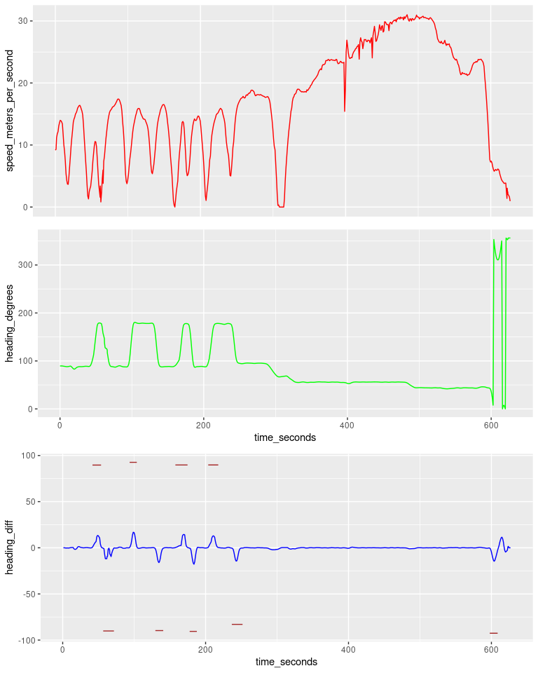

For this trip we observe 9 turns as we have defined them.

### Stops

We will define a stop as an event where speed is approximately 0 m/s for at least 3 seconds, and which is preceded by decelleration. To be preceded by decelleration, the minimum acceleration within the 15 observations immediately preceding the start of a potential stopped vehicle must be < -0.5 m/s.

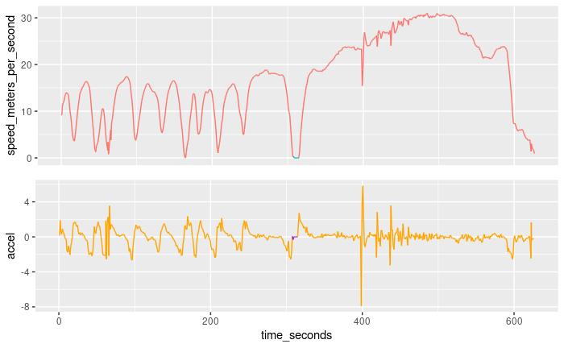

The single period in which the vehicle is stopped is brief and is indicated by different colors in the series.

## Define feature extraction fx

We now define several functions to prep data from a trip file and extract the features according to the logic above.

### prep_trip()

```r
prep_trip <- function(trip_file) {

  trip <- read.csv(paste0("train/", trip_file))
  n <- nrow(trip)

  if(n == 0 | ncol(trip) != 3 |  ## no rows or wrong num of cols
     sum(is.na(trip[,2])) == n | sum(is.na(trip[,3])) == n | ## all missing data either col
     var(trip[, 2], na.rm = T) == 0 | var(trip[,3], na.rm = T) == 0) { ## zero variance column

    bad_trip <<- trip
    stop(paste0("bad trip here: ", trip_file,
                "\n   Speed NA: ", sum(is.na(trip[,2])),
                "\n   Heading NA: ", sum(is.na(trip[,3])),
                "\n   Speed variance: ", var(trip[, 2], na.rm = T),
                "\n   Heading variance: ", var(trip[, 3], na.rm = T) ))
  }

  trip %>%
    imputeTS::na_locf() %>%
    ## turns
    mutate(heading_diff = (heading_degrees - lag(heading_degrees) + 540) %% 360 - 180,
           run = sign(heading_diff) * (abs(heading_diff) > .25)) %>%
    group_by(runid = {runid = rle(run); rep(seq_along(runid$lengths), runid$lengths)}) %>%
    mutate(tot_heading_diff = (last(heading_degrees) - first(heading_degrees) + 540) %% 360 - 180,
           avg_speed = mean(speed_meters_per_second),
           turn_ind = n() > 2 &
             abs(tot_heading_diff) >= 60 &
             avg_speed < 20 &
             n() < 45) %>%
    ungroup() %>%
    mutate(turn_amt = case_when(turn_ind ~ tot_heading_diff, TRUE ~ NA_real_)) %>%
    ## stops
    mutate(accel = speed_meters_per_second - lag(speed_meters_per_second),
           roll_accel_15 = lag(zoo::rollapply(accel, 15, min, align = "right", fill = NA)),
           stop_run = abs(speed_meters_per_second) < .05) %>%
    group_by(stop_runid = {stop_runid = rle(stop_run); rep(seq_along(stop_runid$lengths), stop_runid$lengths)}) %>%
    mutate(stop_ind = n() > 2 & max(stop_run) & first(roll_accel_15) < -.5) %>%
    ungroup() %>%
    return()
}
```

### count_stops()

```r
count_stops <- function(trip = NULL) {
  trip %>%
    filter(stop_ind) %>%
    group_by(stop_runid) %>%
    summarise() %>%
    ungroup() %>%
    nrow %>%
    return()
}
```

### count_turns()

```r
count_turns <- function(trip = NULL) {
  trip %>%
    filter(turn_ind) %>%
    group_by(runid) %>%
    summarise() %>%
    ungroup() %>%
    nrow %>%
    return()
}
```

### plot_trip()

```r
plot_trip <- function(trip_file, return_df = FALSE) {

  trip <- prep_trip(trip_file)
  if(return_df) return(trip)  ## break

  p <- arrangeGrob(
    ## heading over time (clockwise due north)
    trip %>%
      ggplot(aes(time_seconds, heading_degrees, color = turn_ind)) +
      geom_path(aes(group = 1), show.legend = FALSE) +
      ggtitle(trip_file) +
      scale_color_manual(values=c("green", "purple")),
    ## Change in heading
    trip %>%
      ggplot(aes(time_seconds, heading_diff)) +
      geom_path(color = "blue") +
      geom_line(aes(time_seconds, turn_amt), color = "brown"),
    ## speed (meters/sec) over time
    trip %>%
      ggplot(aes(time_seconds, speed_meters_per_second, color = lead(stop_ind))) +
      geom_path(aes(group = 1), show.legend = FALSE) +
      theme(axis.title.x=element_blank(),
            axis.text.x=element_blank(),
            axis.ticks.x=element_blank() ),
    ## acceleration/stops
    trip %>%
      ggplot(aes(time_seconds, accel, color = lead(stop_ind))) +
      geom_path(aes(group = 1), show.legend = FALSE) +
      scale_color_manual(values=c("orange", "blue")),

    ncol = 1
  )
  return(p)
}
```

## Evalute feature logic

I’ll take a sample of trips, 5 from each class, and apply the plotting function defined above to visually check for reasonable results.

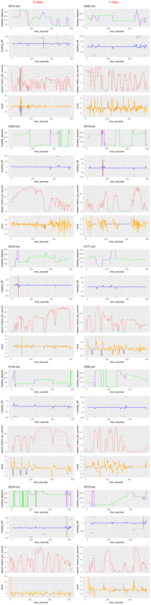

```r
set.seed(42)
small_samp <- train_raw %>%
  select(filename, y_fctr) %>%
  group_by(y_fctr) %>%
  sample_n(5)

plist <- lapply(small_samp %>% pull(filename), plot_trip ) ## apply plot_trip() over sample

grid.arrange(
  do.call(arrangeGrob, list(grobs = plist[1:5],
                            top = textGrob("0-class", gp=gpar(fontsize=15, font=3, col="red")),
                            ncol = 1, as.table = F) ),
  do.call(arrangeGrob, list(grobs = plist[6:10],
                            top = textGrob("1-class", gp=gpar(fontsize=15, font=3, col="red")),
                            ncol = 1, as.table = F) ),
  ncol = 2
)
```

The results seem reasonable, though not perfect. For example, in trip `0973` there appears to be a stop which is missed due to a noisy speed reading, which could be due to measurement error in the sensor or a driver who likes to play with the brake pedal at lights.

One avenue for improvement will be data smoothing - e.g. via smoothing splines, simple kernels/filters, kriging, etc. Another avenue includes techniques based on matrix profiling - for example, motif and shapelet discovery. These methods can all be performed unsupervised or used in a supervised approach were we to label some trips with known counts of turns and stops.

## FE Computational Performance

For a single trip, we must first call `prep_trip()` which reads the relevant file from disk and returns a data.frame object. Then we call each of `count_turns()` and `count_stops()` which takes the data.frame as input and returns a length 1 vector for each. The computational time for a single iteration is shown below:

```r
comp_eval <- function(x) {
  a <- prep_trip("0001.csv")
  b <- count_turns(a)
  c <- count_stops(a)
  return()
}

v <- small_samp %>% pull(filename)

print(paste0("Test performed for ", length(v), " files sequentially"))
```

```
[1] "Test performed for 10 files sequentially"
```

```r
system.time({
  lapply(v, comp_eval )
})
```

```
   user  system elapsed
  0.498   0.004   0.502
```

```r
rm(v, comp_eval)
```

Clock time is about half a second, but CPU (system) time is marginal. Most of the overhead is due to instructions and disk I/O - [virtual] hardware selection is important.

The process will scale over multiple files with O(n) (linear time) complexity.

# Modeling

We turn now to the modeling analysis.

## Extract Training features

First let’s prepare our features for the training set

```r
train_newx <- tibble(filename = NA_character_, stop_count = NA_integer_, turn_count = NA_integer_) %>% slice(-1)

system.time(
  for(i in 1:nrow(train_raw)) {

    f <- train_raw[i,] %>% pull(filename)

    trip_result <- tryCatch({
      trip <- prep_trip(f)
    },
    error = function(cond) {
      message(paste0("prep_trip() failed for file ", f, " with following error: "))
      message(cond)
      return(cond)
    } )

    if(inherits(trip_result, "error")) {
      train_newx %<>% add_row(filename = f, stop_count = NA_integer_, turn_count = NA_integer_)
      next()
    }

    train_newx %<>%
      add_row(filename = f,
              stop_count = count_stops(trip),
              turn_count = count_turns(trip) )

    rm(trip, f)
  }
)
```

```
prep_trip() failed for file 0195.csv with following error:
bad trip here: 0195.csv
   Speed NA: 0
   Heading NA: 0
   Speed variance: 0.365424790314973
   Heading variance: 0
```

```
   user  system elapsed
 60.830   1.177  62.110
```

Bind the 2 new features to the training data, `stop_count` and `turn_count`. The result will be in original order so we do not need to join.

```r
train <- cbind(train_raw, train_newx[,-1])
```

Trip 0195 failed due to zero variance in the heading vector. Counts will be `NA` for this record.

## Impute NA

We will impute the missing values in order to use all observations in modeling.

```r
lhs <- c("turn_count", "stop_count")
rhs <- colnames(train)[!(colnames(train) %in% c(lhs, c("filename", "y_fctr")))]
imp_formula <- paste(paste(lhs, collapse = " + "), paste(rhs, collapse=" + "), sep=" ~ ") %>% as.formula()

imp_formula
```

```
turn_count + stop_count ~ feature1 + feature3 + feature4 + feature6 +
    feature7 + feature9 + feature12 + feature13 + feature14
<environment: 0x55c6feecdef0>
```

```r
train %<>% missRanger(imp_formula,
                      pmm.k = 5,
                      num.trees = 500,
                      sample.fraction = .6,
                      max.depth = 1,
                      data = .,
                      maxiter = 10L,
                      returnOOB = TRUE,
                      seed = 123,
                      verbose = 2)
```

[output not shown]

## Tuning

We will use a random forest classifier as implemented in the `ranger` library. We prefer a simple and computationally fast approach - random forest provides a strong off-the-shelf classifier with few hyperparameters requiring tuning (as compared to say gradient boosting or neural networks) and is extremely parallelizable.

The two main hyperparameters we will tune with repeated cross-validation are: the number of features to randomly select for each potential split (`mtry`); and the minimum number of observations required in each node (`min.node.size`). The latter controls model complexity and overfitting - we will not tune or use `max.depth` which also has the effect of reducing complexity of individual learners.

We will also evaluate two possible split rules - the traditional gini impurity, as well as more recent hellinger distance. The former favors splits which result in imbalanced class distribution within leaf nodes. Hellinger distance by contrast favors splits which result in an even class distribution within leaf nodes; the rule generally results in better (higher) sensitivity, with minimal loss in specificity.[^1]

Setting up our grid and controls for tuning

```r
k <- 10 ## folds
r <- 10 ## repeats
num.trees <- 2000 ## rf does not overfit by num.trees, but through complexity of individual learners

rfGrid <- expand.grid(mtry = 1:4,
                      min.node.size = seq(15, 30, 5),
                      splitrule = c("gini", "hellinger") )

seeds <- hsbtools::make_seeds(grid = rfGrid,
                              k = k,
                              r = r,
                              alpha.seed = 4242)

trnCtrl <- caret::trainControl(method = "repeatedcv",
                               number = k,
                               repeats = r,
                               summaryFunction = twoClassSummary,
                               seeds = seeds,
                               returnData = FALSE,
                               classProbs = TRUE,
                               savePredictions = FALSE)
```

Run the tuning procedure

```r
rf.cv <- caret::train(y_fctr ~ .,
                      method = "ranger",
                      verbose = F,
                      tuneGrid = rfGrid,
                      trControl = trnCtrl,
                      num.trees = num.trees,
                      importance = "impurity", ## feature importance basis
                      metric = "ROC", ## poorly named, AUC really
                      data = train[, -1], ## omit filename
                      na.action = na.fail) ## no NAs, or else do not move past them silently
```

View the estimated AUC across our hyperparameter grid

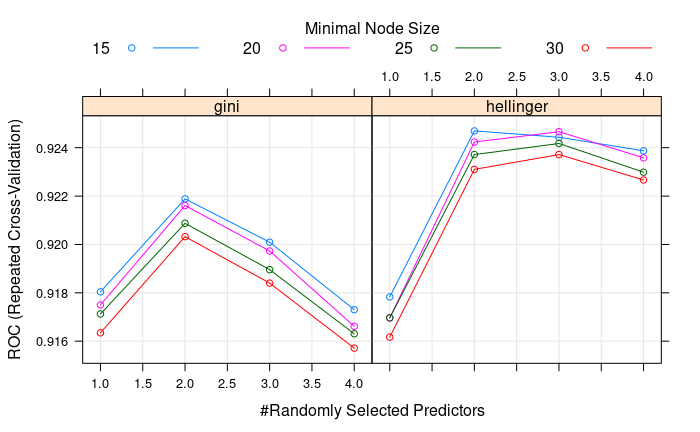

We will select the best result from the above set of evaluations - hellinger distance with `mtry = 2` and `min.node.size = 15`

## Final rf model

Now train the model using the optimal hyperparameters. We will plot feature importance based on gini impurity.

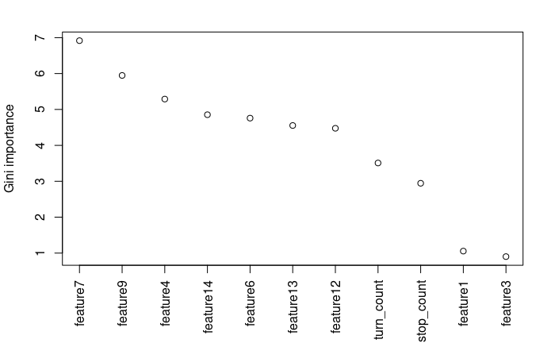

## Model Inference

We want to understand the nature of the relationship between our features and the response. Since there is just a handful of features, we can look at individual conditional expectation (ICE) plots for each. Like partial dependence plots, these show the average marginal effect of a feature, but in addition they show the marginal effect for individual observations. This helps us understand if there were important interactions between variables learned in our forest.

We are selecting 4 of the 11 features to plot below

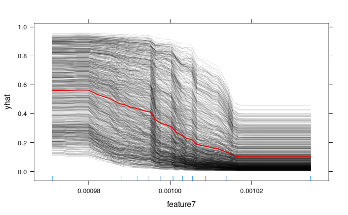

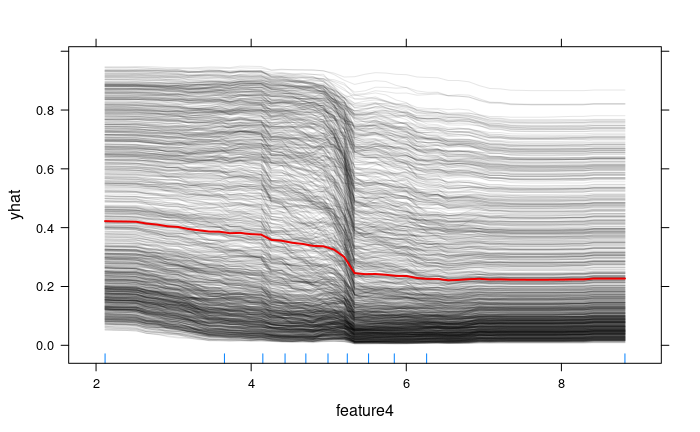

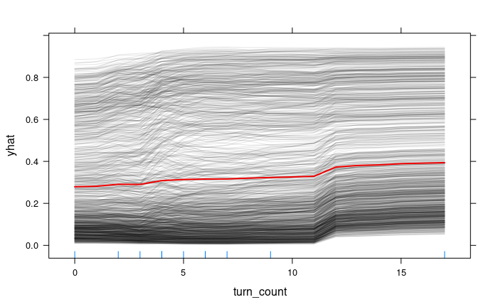

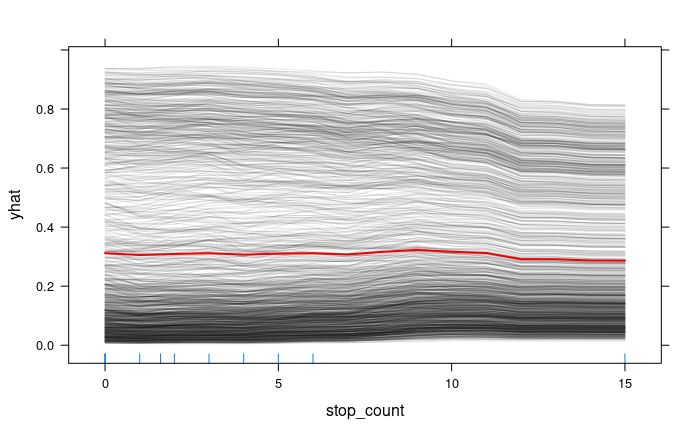

```r
ice <- vector("list", length = 4)
names(ice) <- names(varImp)[c(1,3,8,9)]

for (i in 1:length(ice)) {
  icePartial <- partial(rf.1,
                        pred.var = names(ice)[i],
                        pred.fun = function(object, newdata) predict(object, newdata)$predictions[,2])
  ice[[i]] <- plotPartial(icePartial, rug = TRUE, train = train, alpha = 0.1)
}

lapply(ice, plot)
```

The marginal effect of `stop_count` appears to be weak and perhaps counter-intuitive. We should revisit the extraction logic for this feature, or perhaps consider other features which more completely describe driving behavior - repeated stopping at low speed, hard stopping, rapid deceleration to a near stop, etc.

`knitr::knit_exit()`

```r
set.seed(42)
small_samp <- train_raw %>%
  select(filename, y) %>%
  group_by(y) %>%
  sample_n(5)

plist <- lapply(small_samp %>% pull(filename), plot_trip )
grid.arrange(
  do.call(arrangeGrob, list(grobs = plist[1:5],
                            top = textGrob("0-class", gp=gpar(fontsize=15, font=3, col="red")),
                            ncol = 1, as.table = F) ),
  do.call(arrangeGrob, list(grobs = plist[6:10],
                            top = textGrob("1-class", gp=gpar(fontsize=15, font=3, col="red")),
                            ncol = 1, as.table = F) ),
  ncol = 2
)
```

Nothing jumps out from these time series as obviously separating the two classes. So we will proceed with naive/kitchen sink feature extraction rather than something more informed.

```r
## tsfeatures
feat <- tsfeatures(lapply(mts_train,))

# run function
feat.speed <- extract_features(df=tbl_train,
                               group_var = "trip_id",
                               value_var="speed_meters_per_second",
                               features="all")
feat.heading <- extract_features(df=tbl_train,
                                 group_var = "trip_id",
                                 value_var="heading_degrees",
                                 features="all")

# convert list to data.frame (MapReduce)
final.df <- features_to_df(out.list, data.format="wide", group_var = "id")
```

```r
mvc <- tsclust(mts_train %>% na_locf(), k = 10, distance = "gak", seed = 42 )
# Note how the variables of each series are appended one after the other in the plot
plot(mvc, labels = list(nudge_x = -10, nudge_y = 1))
a <- predict(mvc, newdata = mts_train)
```

```r
test <- fdapace::FPCA(speed, time,
                      optns = list(plot = TRUE))
```

```r
dpos <- function(dist_m, heading, lat) {
  dx <- 0
  dy <- 0
  if(dist_m > 0) {
    dx <- dist_m*sin(heading)/(111320*cos(lat))
    dy <- dist_m*cos(heading)/110540
  }
  return(c(dx, dy))
}
```

```r
dat <- read.csv("test/1712.csv")
dat %<>%
  mutate(mean_speed = (speed_meters_per_second + lead(speed_meters_per_second))/2,
         speed_wtd_heading = (speed_meters_per_second * heading_degrees +
                                lead(speed_meters_per_second) * lead(heading_degrees)) / (mean_speed*2),
         dist_meters = (lead(time_seconds, default = NA) - time_seconds) * mean_speed,
         lat = NA_real_, lon = NA_real_, dlat = NA_real_, dlon = NA_real_)

for(i in 1:(nrow(dat)-1)) {
  if(i == 1) { ## start at Root HQ
    dat[i, "lat"] <- 39.9586645641008
    dat[i, "lon"] <- -82.9977805
  } else {  ## drive around Columbus and beyond without regard for roadways
    dat[i, "lat"] <- dat[i-1, "lat"] + dat[i-1, "dlat"]
    dat[i, "lon"] <- dat[i-1, "lon"] + dat[i-1, "dlon"]
  }

  d <- dpos(dist_m = dat[i, "dist_meters"], heading = dat[i, "speed_wtd_heading"], lat = dat[i, "lat"])
  dat[i, "dlon"] <- d[1]
  dat[i, "dlat"] <- d[2]
  rm(d)
}


dat %>%
  ggplot(aes(lon, lat)) +
  coord_fixed(xlim = c(min(dat$lon), max(dat$lon)),
              ylim = c(min(dat$lat), max(dat$lat))) +
  geom_path()
```

[^1]: Lyon et al., Hellinger Distance Trees for Imbalanced Streams, 2014, https://arxiv.org/pdf/1405.2278.pdf